# IBM HR Analysis

### 1.3 Descriptive Analysis

- Analyze the distribution of each variable using histograms, box plots, and density plots
- Check for skewness and kurtosis
- Calculate summary statistics such as mean, median, mode, and standard deviation

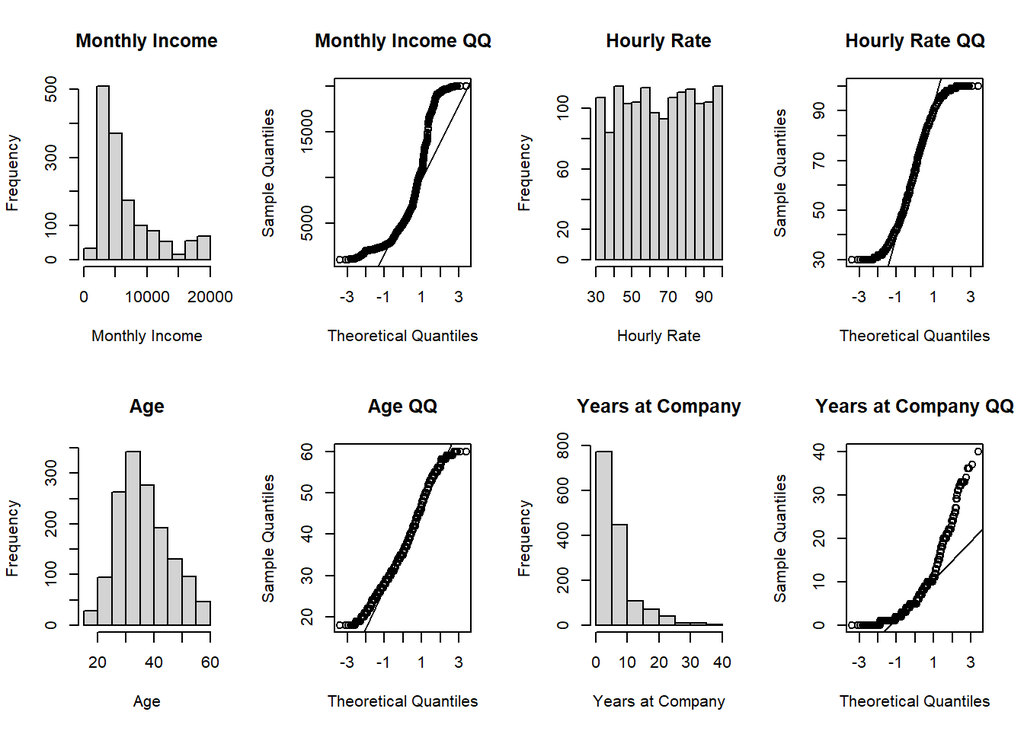

```r
# analyze the distribution of each variable using histograms, QQ plots, and QQ lines
par(mfrow = c(2, 4))
hist(hr$MonthlyIncome, main = "Monthly Income", xlab = "Monthly Income")
qqnorm(hr$MonthlyIncome, main = "Monthly Income QQ")
qqline(hr$MonthlyIncome)

hist(hr$HourlyRate, main = "Hourly Rate", xlab = "Hourly Rate")
qqnorm(hr$HourlyRate, main = "Hourly Rate QQ")
qqline(hr$HourlyRate)

hist(hr$Age, main = "Age", xlab = "Age")
qqnorm(hr$Age, main = "Age QQ")
qqline(hr$Age)

hist(hr$YearsAtCompany, main = "Years at Company", xlab = "Years at Company")
qqnorm(hr$YearsAtCompany, main = "Years at Company QQ")
qqline(hr$YearsAtCompany)
```

```r
# check for skewness and kurtosis
skewness(hr$MonthlyIncome)
```

```
## [1] 1.368419
```

```r
kurtosis(hr$MonthlyIncome)
```

```
## [1] 3.997738
```

```r
skewness(hr$YearsAtCompany)
```

```
## [1] 1.762728
```

```r
kurtosis(hr$YearsAtCompany)
```

```
## [1] 6.918057
```

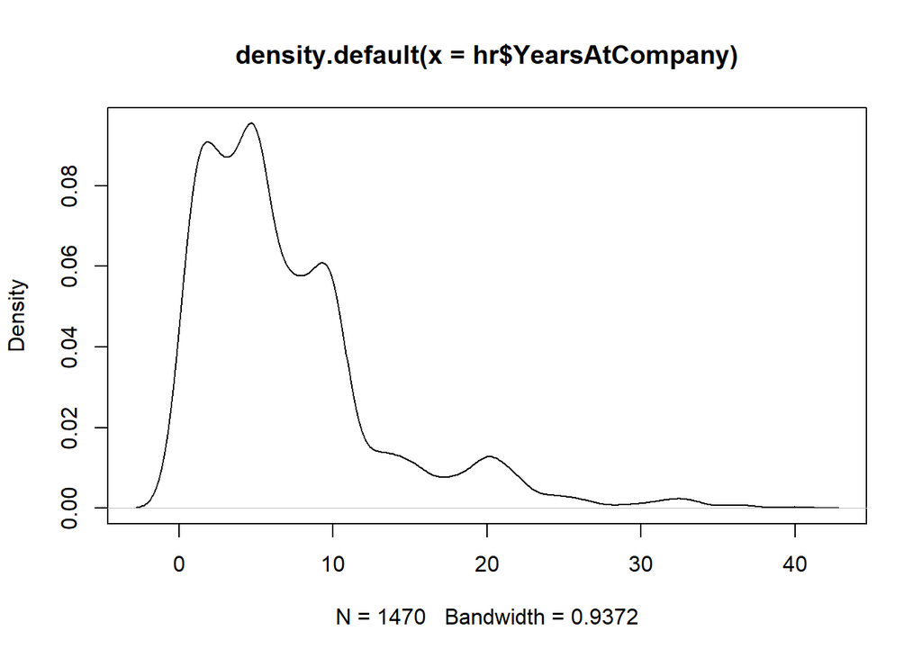

```r
#Density
par(mfrow = c(1, 1))
plot(density(hr$YearsAtCompany))
```

```r
# calculate summary statistics such as mean, median, mode, and standard deviation
deshr <- hr[, c("DailyRate", "HourlyRate", "MonthlyIncome", "MonthlyRate", "TotalWorkingYears", "YearsAtCompany", "TrainingTimesLastYear", "YearsInCurrentRole", "YearsSinceLastPromotion", "YearsWithCurrManager")]
describe(deshr)
```

```
##                         vars    n     mean      sd  median  trimmed     mad
## DailyRate                  1 1470   802.49  403.51   802.0   803.83  510.01
## HourlyRate                 2 1470    65.89   20.33    66.0    66.02   26.69
## MonthlyIncome              3 1470  6502.93 4707.96  4919.0  5667.24 3260.24
## MonthlyRate                4 1470 14313.10 7117.79 14235.5 14286.48 9201.76
## TotalWorkingYears          5 1470    11.28    7.78    10.0    10.37    5.93
## YearsAtCompany             6 1470     7.01    6.13     5.0     5.99    4.45
## TrainingTimesLastYear      7 1470     2.80    1.29     3.0     2.72    1.48
## YearsInCurrentRole         8 1470     4.23    3.62     3.0     3.85    4.45
## YearsSinceLastPromotion    9 1470     2.19    3.22     1.0     1.48    1.48
## YearsWithCurrManager      10 1470     4.12    3.57     3.0     3.77    4.45
##                          min   max range  skew kurtosis     se
## DailyRate                102  1499  1397  0.00    -1.21  10.52
## HourlyRate                30   100    70 -0.03    -1.20   0.53
## MonthlyIncome           1009 19999 18990  1.37     0.99 122.79
## MonthlyRate             2094 26999 24905  0.02    -1.22 185.65
## TotalWorkingYears          0    40    40  1.11     0.91   0.20
## YearsAtCompany             0    40    40  1.76     3.91   0.16
## TrainingTimesLastYear      0     6     6  0.55     0.48   0.03
## YearsInCurrentRole         0    18    18  0.92     0.47   0.09
## YearsSinceLastPromotion    0    15    15  1.98     3.59   0.08
## YearsWithCurrManager       0    17    17  0.83     0.16   0.09
```

```r
# aggregate
aggregate(MonthlyIncome ~ Gender, hr, mean)
```

```
##   Gender MonthlyIncome
## 1 Female      6686.566
## 2   Male      6380.508
```

```r
aggregate(MonthlyIncome ~ YearsInCurrentRole, hr, mean)
```

```
##    YearsInCurrentRole MonthlyIncome
## 1                   0      5082.488
## 2                   1      5416.298
## 3                   2      5179.616
## 4                   3      5522.644
## 5                   4      6153.702
## 6                   5      5502.333
## 7                   6     10585.946
## 8                   7      7237.351
## 9                   8      8563.809
## 10                  9      9177.776
## 11                 10     10348.448
## 12                 11      7892.727
## 13                 12     10338.400
## 14                 13      8301.143
## 15                 14     10066.818
## 16                 15     14874.125
## 17                 16     13591.286
## 18                 17     16700.000
## 19                 18     19768.000
```

```r
aggregate(YearsAtCompany ~ Attrition, hr, mean)
```

```
##   Attrition YearsAtCompany
## 1        No       7.369019
## 2       Yes       5.130802
```

### 1.4 Bivariate Analysis

- Analyze the relationship between two variables using scatter plots, line plots, and box plots
- Check for correlation between numerical variables using a correlation matrix
- Check for association between categorical variables using a chi-square test

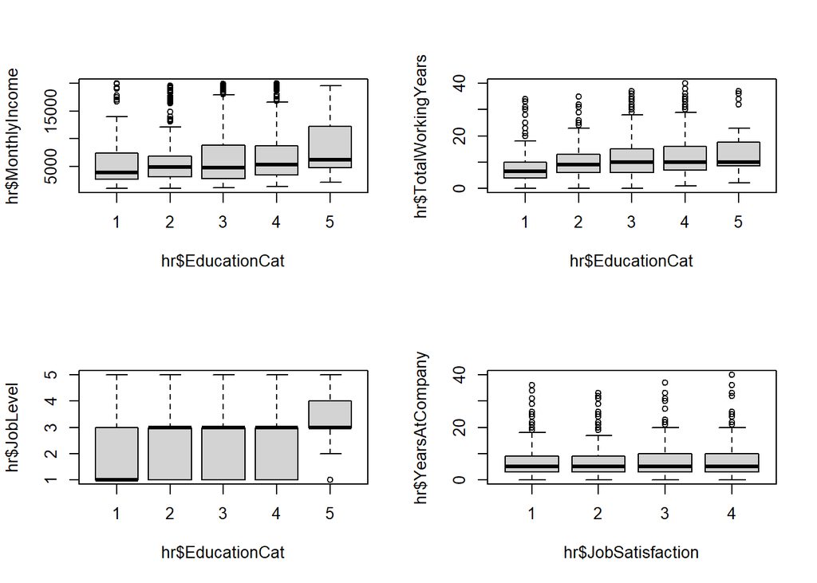

```r
# Analyze the relationship between two variables using scatter plots, line plots, and box plots
par(mfrow = c(2, 2))
boxplot(hr$MonthlyIncome ~ hr$EducationCat)
boxplot(hr$TotalWorkingYears ~ hr$EducationCat)

boxplot(hr$JobLevel ~ hr$EducationCat)
boxplot(hr$YearsAtCompany~ hr$JobSatisfaction)
```

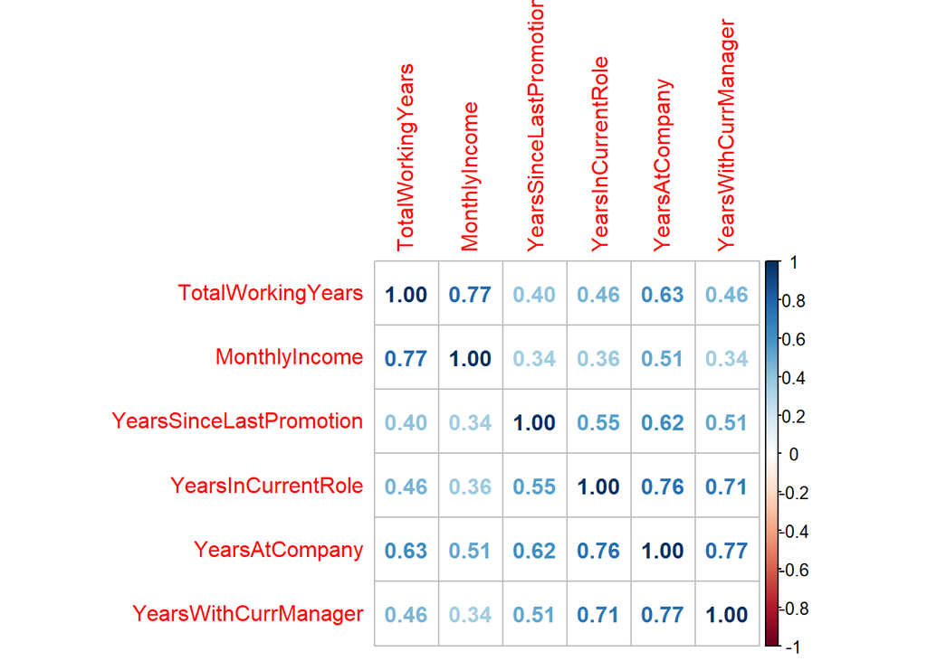

```r
# Check for correlation between numerical variables using a correlation matrix
par(mfrow = c(1, 1))
corrplot(cor(hr[, c("TotalWorkingYears", "YearsSinceLastPromotion", "YearsInCurrentRole","MonthlyIncome", "YearsAtCompany", "YearsWithCurrManager")]), order = "hclust", method = "number")
```

```r
# Check for association between categorical variables using a chi-square test
chisq.test(hr$Attrition, hr$JobRole)
```

```
##
##  Pearson's Chi-squared test
##
## data:  hr$Attrition and hr$JobRole
## X-squared = 86.19, df = 8, p-value = 2.752e-15
```

```r
chisq.test(hr$Attrition, hr$MaritalStatus)
```

```
##
##  Pearson's Chi-squared test
##
## data:  hr$Attrition and hr$MaritalStatus
## X-squared = 46.164, df = 2, p-value = 9.456e-11
```

```r
chisq.test(hr$Attrition, hr$OverTime)
```

```
##
##  Pearson's Chi-squared test with Yates' continuity correction
##
## data:  hr$Attrition and hr$OverTime
## X-squared = 87.564, df = 1, p-value < 2.2e-16
```

```r
chisq.test(hr$Attrition, hr$WorkLifeBalance)
```

```
##
##  Pearson's Chi-squared test
##
## data:  hr$Attrition and hr$WorkLifeBalance
## X-squared = 16.325, df = 3, p-value = 0.0009726
```